# Call Center Report

### by Mercy Faith Nyambura Kariuki

### Introduction

This dataset contains call records from different call centers. Our purpose is to explore the effective of each dataset based on their response time, reason of calling and the average of a calls among other features that we'll explore.

> **[Dataset Link](https://data.world/markbradbourne/rwfd-real-world-fake-data/workspace/file?filename=Call+Center.csv)**

Call_center.csv data description:

> - id - caller id
> - customer_name - name of the customer
> - sentiment - `Very Negative`, `Negative`, `Neutral`, `Positive`, `Very Positive`
> - call_timestamp - day when the call was made
> - reason - `Billing Question`, `Service Outage`, `Payments`
> - city - city from where the call was made
> - state - state from where the call was made
> - channel - `Call-Center`, `Chatbot`, `Email`, `Web`
> - response_time - `Within SLA`, `Above SLA`, `Below SLA`
> - call duration in minutes - duration of call in minutes
> - call_center - `Los Angeles/CA`, `Baltimore/MD`, `Denver/CO`, `Chicago/IL`

Stages of the project

1. Data Aquisition

2. Data Preprocessing

3. ExploratoryDataAnalysis

4. Portrait of the user of each region

5. Research Results

# Stage 1. Data acquisition

> **Let's examine the data provided for the project.**

```python
# import all packages and set plots to be embedded inline
import pandas as pd
import numpy as np
import seaborn as sns
import matplotlib.pyplot as plt
import warnings

%matplotlib inline
warnings.filterwarnings("ignore")
```

```python
#let's upload the dataset and view the table
calls=pd.read_csv('C:/Users/kariu/OneDrive/Desktop/Data Science/Call Center Data/Call_Center.csv')
calls.head()
```

|  | id | customer_name | sentiment | csat_score | call_timestamp | reason | city | state | channel | response_time | call duration in minutes | call_center |
| --- | --- | --- | --- | --- | --- | --- | --- | --- | --- | --- | --- | --- |
| 0 | DKK-57076809-w-055481-fU | Analise Gairdner | Neutral | 7.0 | 10/29/2020 | Billing Question | Detroit | Michigan | Call-Center | Within SLA | 17 | Los Angeles/CA |
| 1 | QGK-72219678-w-102139-KY | Crichton Kidsley | Very Positive | NaN | 10/05/2020 | Service Outage | Spartanburg | South Carolina | Chatbot | Within SLA | 23 | Baltimore/MD |
| 2 | GYJ-30025932-A-023015-LD | Averill Brundrett | Negative | NaN | 10/04/2020 | Billing Question | Gainesville | Florida | Call-Center | Above SLA | 45 | Los Angeles/CA |
| 3 | ZJI-96807559-i-620008-m7 | Noreen Lafflina | Very Negative | 1.0 | 10/17/2020 | Billing Question | Portland | Oregon | Chatbot | Within SLA | 12 | Los Angeles/CA |
| 4 | DDU-69451719-O-176482-Fm | Toma Van der Beken | Very Positive | NaN | 10/17/2020 | Payments | Fort Wayne | Indiana | Call-Center | Within SLA | 23 | Los Angeles/CA |

```python
calls.dtypes
```

```
id                           object
customer_name                object
sentiment                    object
csat_score                  float64
call_timestamp               object
reason                       object
city                         object
state                        object
channel                      object
response_time                object
call duration in minutes      int64
call_center                  object
dtype: object
```

*The `call_timestamp` is of the wrong data format*

```python
calls.isnull().sum()
```

```
id                              0
customer_name                   0
sentiment                       0
csat_score                  20670
call_timestamp                  0
reason                          0
city                            0
state                           0
channel                         0
response_time                   0
call duration in minutes        0
call_center                     0
dtype: int64
```

*`csat_score` has null values that conribute to 60% of the total scores. In this case, we'll fill the null values with the mean*

```python
#getting shape of the csat_score
calls.csat_score.shape
```

```
(32941,)
```

```python
# getting general information about the data in the calls table
calls.info()
```

```
<class 'pandas.core.frame.DataFrame'>
RangeIndex: 32941 entries, 0 to 32940
Data columns (total 12 columns):
 #   Column                    Non-Null Count  Dtype
---  ------                    --------------  -----
 0   id                        32941 non-null  object
 1   customer_name             32941 non-null  object
 2   sentiment                 32941 non-null  object
 3   csat_score                12271 non-null  float64
 4   call_timestamp            32941 non-null  object
 5   reason                    32941 non-null  object
 6   city                      32941 non-null  object
 7   state                     32941 non-null  object
 8   channel                   32941 non-null  object
 9   response_time             32941 non-null  object
 10  call duration in minutes  32941 non-null  int64
 11  call_center               32941 non-null  object
dtypes: float64(1), int64(1), object(10)
memory usage: 3.0+ MB
```

```python
# descriptive statistics of the dataset
calls.describe()
```

|  | csat_score | call duration in minutes |
| --- | --- | --- |
| count | 12271.000000 | 32941.000000 |
| mean | 5.548448 | 25.021159 |
| std | 2.371059 | 11.816218 |
| min | 1.000000 | 5.000000 |
| 25% | 4.000000 | 15.000000 |
| 50% | 5.000000 | 25.000000 |
| 75% | 7.000000 | 35.000000 |
| max | 10.000000 | 45.000000 |

```python
#shape of calls dataset
calls.shape
```

```
(32941, 12)
```

```python
#checking for duplicate values
calls.duplicated().sum()
```

```
0
```

```python
#checking unique value in various columns
print(f"Sentiments: {calls.sentiment.unique()}")
print(f"Calling reasons: {calls.reason.unique()}")
print(f"Channels used: {calls.channel.unique()}")
print(f"Call centers: {calls.call_center.unique()}")
print(f"Response time: {calls.response_time.unique()}")
```

```
Sentiments: ['Neutral' 'Very Positive' 'Negative' 'Very Negative' 'Positive']
Calling reasons: ['Billing Question' 'Service Outage' 'Payments']
Channels used: ['Call-Center' 'Chatbot' 'Email' 'Web']
Call centers: ['Los Angeles/CA' 'Baltimore/MD' 'Denver/CO' 'Chicago/IL']
Response time: ['Within SLA' 'Above SLA' 'Below SLA']
```

```python
# check for null values
calls.isnull().sum().sum()
```

```
20670
```

```python
calls.isnull().sum()
```

```
id                              0
customer_name                   0
sentiment                       0
csat_score                  20670
call_timestamp                  0
reason                          0
city                            0
state                           0
channel                         0
response_time                   0
call duration in minutes        0
call_center                     0
dtype: int64
```

### What is the structure of your dataset?

sentiment: Neutral, Positive, Very Positive, Negative, Very Negative  
reason: Billing Question, Service Outage, Payments  
channel: Call-Center, Chatbot, Email, Web  
call center: Los Angeles/CA, Baltimore/MD, Denver/CO, Chicago/IL response time: Within SLA, Below SLA, Above SLA

### What is/are the main feature(s) of interest in your dataset?

I'm most interested in figuring out which call centers received most calls, the prevailing call reason and centers that responded to calls as per the service level agreement (SLA)

# Stage 2. Data preprocessing

> - Drop `customer_name`. We don't need customer names to conduct the call center analysis
> - Convert `call_timestamp` datatype to date
> - `csat_score` has 20,670 null values which constitutes to 62% of the score. Conver NaN to mean of csat_score

> **Create a copy of the dataset**

```python
calls_clean=calls.copy()
```

## **Define:**

> Drop `customer_name`, `id`. We don't need a customer's name or the ID to perform our analysis

## **Code**

```python
#display columns
calls_clean.columns
```

```
Index(['id', 'customer_name', 'sentiment', 'csat_score', 'call_timestamp',
       'reason', 'city', 'state', 'channel', 'response_time',
       'call duration in minutes', 'call_center'],
      dtype='object')
```

```python
#drop customer_name column
calls_clean=calls_clean.drop('customer_name', axis=1)
```

```python
#drop id column
calls_clean=calls_clean.drop('id', axis=1)
```

## **Test**

```python
#confirm that customer name and id columns are dropped
calls_clean.columns
```

```
Index(['sentiment', 'csat_score', 'call_timestamp', 'reason', 'city', 'state',
       'channel', 'response_time', 'call duration in minutes', 'call_center'],
      dtype='object')
```

## **Define:**

> Convert `call_timestamp` to date

## **Code**

```python
#converting call timestamp to datetime format
calls_clean['call_timestamp'] = pd.to_datetime(calls_clean['call_timestamp'])
```

```python
#confirm the conversion
calls_clean.info()
```

```
<class 'pandas.core.frame.DataFrame'>
RangeIndex: 32941 entries, 0 to 32940
Data columns (total 10 columns):
 #   Column                    Non-Null Count  Dtype
---  ------                    --------------  -----
 0   sentiment                 32941 non-null  object
 1   csat_score                12271 non-null  float64
 2   call_timestamp            32941 non-null  datetime64[ns]
 3   reason                    32941 non-null  object
 4   city                      32941 non-null  object
 5   state                     32941 non-null  object
 6   channel                   32941 non-null  object
 7   response_time             32941 non-null  object
 8   call duration in minutes  32941 non-null  int64
 9   call_center               32941 non-null  object
dtypes: datetime64[ns](1), float64(1), int64(1), object(7)
memory usage: 2.5+ MB
```

## **Define:**

> `csat_score` has 20,670 null values which constitutes to 62% of the score. Convert the null values to mean of csat_score

```python
#display the values in the csat score column
calls_clean.csat_score.unique()
```

```
array([ 7., nan,  1.,  5.,  8.,  4.,  2.,  6.,  9.,  3., 10.])
```

## **Code**

```python
# replace the nan values with the mean
mean=calls_clean['csat_score'].mean()
calls_clean['csat_score']=calls_clean['csat_score'].fillna(mean)
```

## **Test**

```python
# confrim the null values have been dealt with
calls_clean.isnull().sum()
```

```
sentiment                   0
csat_score                  0
call_timestamp              0
reason                      0
city                        0
state                       0
channel                     0
response_time               0
call duration in minutes    0
call_center                 0
dtype: int64
```

# Stage 3. Exploratory data analysis

# Part I

## Univariate Exploration

## Which call center received highest number of calls?

[figure not shown]

```python
# Return the Series having unique values
x = calls_clean['call_center'].unique()

# Return the Series having frequency count of each unique value
y = calls_clean['call_center'].value_counts(sort=True)
# Format size of the chart
plt.figure(figsize=(10,8))

# Add data to the chart
a=sns.barplot(x,y,color='orange')
a.bar_label(a.containers[0], fontsize=20, weight="bold")

# Labeling the axes
plt.xlabel('Call center', fontsize=20)
plt.ylabel('Count', fontsize=20)

# Add title
plt.title("Total Calls by Call Center", fontsize=20, weight="bold");


plt.grid(axis="y",color = 'grey', linestyle = '--', linewidth = 1.5)
plt.show()
```

## What's the most sentiment recieved from the customers

[figure not shown]

```python
# Return the Series having unique values
x = calls_clean['sentiment'].unique()

# Return the Series having frequency count of each unique value
y = calls_clean['sentiment'].value_counts(sort=True)

# Format size of the chart
plt.figure(figsize=(10,8))

# Add data to the chart
b=sns.barplot(x,y,color='purple')
b.bar_label(a.containers[0], fontsize=20, weight="bold")

# Labeling the axes
plt.xlabel('Sentiment Received', fontsize=20)
plt.ylabel('Count', fontsize=20)

# Add title
plt.title("Number of Calls received by Customer Sentiment", fontsize=20, weight="bold");


plt.grid(axis="y",color = 'grey', linestyle = '--', linewidth = 1.5)
plt.show()
```

## What is the prevailing reason for the calls made?

[figure not shown]

```python
# Return the Series having unique values
x = calls_clean['reason'].unique()

# Return the Series having frequency count of each unique value
y = calls_clean['reason'].value_counts(sort=False)

# Format size of the chart
plt.figure(figsize=(10,8))

# Add data to the chart
c=sns.barplot(x,y,color='green')
c.bar_label(a.containers[0], fontsize=20, weight="bold")

# Labeling the axes
plt.xlabel('Reason', fontsize=20)
plt.ylabel('Count', fontsize=20)

# Add title
plt.title("Number of calls received by reason", fontsize=20, weight="bold");


plt.grid(axis="y",color = 'grey', linestyle = '--', linewidth = 1.5)
plt.show()
```

**71.2% of the calls received were due to billing enquires.**

## What are the number of calls received accoring to the SLA agreement

[figure not shown]

```python
# Return the Series having unique values
x = calls_clean['response_time'].unique()

# Return the Series having frequency count of each unique value
y = calls_clean['response_time'].value_counts(sort=False)

# Format size of the chart
plt.figure(figsize=(10,8))

# Add data to the chart
d=sns.barplot(x,y,color='green')
d.bar_label(a.containers[0], fontsize=20, weight="bold")

# Labeling the axes
plt.xlabel('Response time', fontsize=20)
plt.ylabel('Count', fontsize=20)

# Add title
plt.title("Number of calls by respone time", fontsize=20, weight="bold");


plt.grid(axis="y",color = 'grey', linestyle = '--', linewidth = 1.5)
plt.show()
```

# Part II

## 1. Which call center received the most calls?

```python
#total call count per call center
calls_clean['call_center'].value_counts()
```

```
Los Angeles/CA    13734
Baltimore/MD      11012
Chicago/IL         5419
Denver/CO          2776
Name: call_center, dtype: int64
```

> **Let's visualize the above findings**

```python
Los_Angeles_CA=13734/calls_clean['call_center'].value_counts().sum()*100
Baltimore_MD=11012/calls_clean['call_center'].value_counts().sum()*100
Chicago_IL=5419/calls_clean['call_center'].value_counts().sum()*100
Denver_CO=2776/calls_clean['call_center'].value_counts().sum()*100

print(f'Los Angeles/CA: ', Los_Angeles_CA)
print(f'Baltimore/MD: ', Baltimore_MD)
print(f'Chicago/IL: ', Chicago_IL)
print(f'Denver/CO: ', Denver_CO)
```

```
Los Angeles/CA:  41.69272335387511
Baltimore/MD:  33.42946480070429
Chicago/IL:  16.450623842627728
Denver/CO:  8.427188002792873
```

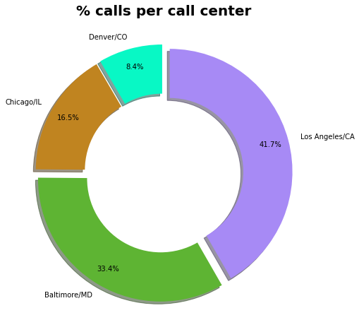

```python
#a78af5, #8bfeae, #5eb433, #c08420 ,#c0b420, #f36007
colors = ['#a78af5', '#5eb433','#c08420', '#08f8c5', '#c0b420']
labels=['Los Angeles/CA', 'Baltimore/MD', 'Chicago/IL', 'Denver/CO']
sizes= [41.6, 33.4, 16.4, 8.4]
explode = (0.05, 0.05, 0.05, 0.05)

# format pie chart size
plt.figure(figsize=[8,8])

# Add formatting to pie chart
plt.pie(calls_clean['call_center'].value_counts(),
        labels=labels,
        autopct='%1.1f%%',
        startangle=90,
        counterclock=False,
        wedgeprops={'width':0.4},
        colors=colors,
        shadow=True,
        pctdistance=0.85,
        explode=explode,);
plt.rcParams['font.size']=15

# Add title and formatting
plt.title("% calls per call center", fontsize=20, weight="bold")


plt.show()
```

> **This pie chart shows that Los Angeles recieved most call followed by Baltimore**

## 2. Of the calls received, what's the highest sentiment?

```python
calls_clean['sentiment'].value_counts()
```

```
Negative         11063
Neutral           8754
Very Negative     6026
Positive          3928
Very Positive     3170
Name: sentiment, dtype: int64
```

```python
Negative=11063/calls_clean['sentiment'].value_counts().sum()*100
Very_Negative=8754/calls_clean['sentiment'].value_counts().sum()*100
Neutral=6026/calls_clean['sentiment'].value_counts().sum()*100
Positive=3928/calls_clean['sentiment'].value_counts().sum()*100
Very_Positive=3170/calls_clean['sentiment'].value_counts().sum()*100

print(f'Negative: ', Negative)
print(f'Very Negative: ', Very_Negative)
print(f'Neutral: ', Neutral)
print(f'Positive: ', Positive)
print(f'Very Positive: ', Very_Positive)
```

```
Negative:  33.58428705868067
Very Negative:  26.57478522206369
Neutral:  18.29331228560153
Positive:  11.924349594729971
Very Positive:  9.623265838924137
```

[figure not shown]

```python
#93cde4, #f46f83, #cc0d5e, #a40dcc, #cc6d0d, #f68616
colors = ['#f36007', '#f46f83','#cc0d5e', '#8bfeae', '#c08420']
labels=['Negative', 'Very Negative', 'Neutral', 'Positive', 'Very Positive']
sizes= [33.5, 26.5, 18.2, 11.2, 9.6]
explode = (0.05, 0.05, 0.05, 0.05, 0.05)


# pie chart size
plt.figure(figsize=[8,8])

# pie chart formatting
plt.pie(calls_clean['sentiment'].value_counts(),
        labels=labels,
        autopct='%1.1f%%',
        startangle=90,
        counterclock=False,
        wedgeprops={'width':0.4},
        colors=colors,
        shadow=True,
        pctdistance=0.85,
        explode=explode,);
plt.rcParams['font.size']=15

# Add title
plt.title("% sentiments received", weight="bold", fontsize=20)

plt.show()
```

**Negative sentiments are the most recieved while Very Psotive sentiments are the least recieved. This questions the level of quality service to the customers.**

## 3. What's the prevailing reason of the calls recieved?

```python
# total numbers per reason
calls_clean['reason'].value_counts()
```

```
Billing Question    23462
Payments             4749
Service Outage       4730
Name: reason, dtype: int64
```

```python
Billing_Question=23462/calls_clean['reason'].value_counts().sum()*100
Payments=4749/calls_clean['reason'].value_counts().sum()*100
Service_Outage=4730/calls_clean['reason'].value_counts().sum()*100

print(f'Billing Question: ', Billing_Question)
print(f'Payments: ', Payments)
print(f'Service Outage: ', Service_Outage)
```

```
Billing Question:  71.22431013023284
Payments:  14.416684375094865
Service Outage:  14.359005494672292
```

[figure not shown]

```python
#DAF7A6, #FFC300, #FF5733, #C70039, #900C3F, #581845
colors = ['#c08420', '#FFC300','#FF5733']
labels=['Billing Question', 'Payments', 'Service Outage']
sizes= [71.2, 14.4, 14.3]
explode = (0.05, 0.05, 0.05)

# pie chart size
plt.figure(figsize=[8,8])

# pie chart formatting
plt.pie(calls_clean['response_time'].value_counts(),
        labels=labels,
        autopct='%1.1f%%',
        startangle=90,
        counterclock=False,
        wedgeprops={'width':0.4},
        colors=colors,
        shadow=True,
        pctdistance=0.85,
        explode=explode,);
plt.rcParams['font.size']=15


# title
plt.title("% call received by reason", fontsize=20, weight="bold")

plt.show()
```

## 4. What's the number of calls that satisifed or didn't satisfy the Service Level Agreement?

```python
# total counts per response time
calls_clean['response_time'].value_counts()
```

```
Within SLA    20625
Below SLA      8148
Above SLA      4168
Name: response_time, dtype: int64
```

> **Let's visualize these findings**

```python
Within_SLA=20625/calls_clean['response_time'].value_counts().sum()*100
Below_SLA=8148/calls_clean['response_time'].value_counts().sum()*100
Above_SLA=4168/calls_clean['response_time'].value_counts().sum()*100

print(f'Within SLA: ', Within_SLA)
print(f'Below SLA: ', Below_SLA)
print(f'Above SLA: ', Above_SLA)
```

```
Within SLA:  62.61194256397802
Below SLA:  24.735132509638444
Above SLA:  12.652924926383536
```

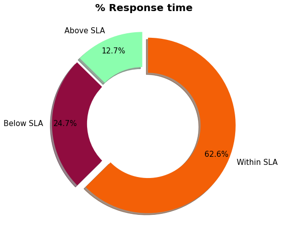

```python
# Pie chart '#ff9999',#ff9999','#66b3ff','#99ff99'
colors = ['#f36007', '#900C3F','#8bfeae']
labels=['Within SLA', 'Below SLA', 'Above SLA']
sizes= [62.6, 24.7, 12.6]
explode = (0.05, 0.05, 0.05)

# pie chart size
plt.figure(figsize=[8,8])

#pie chart formatting
plt.pie(calls_clean['response_time'].value_counts(),
        labels=labels,
        autopct='%1.1f%%',
        startangle=90,
        counterclock=False,
        wedgeprops={'width':0.4},
        colors=colors,
        shadow=True,
        pctdistance=0.85,
        explode=explode,);
plt.rcParams['font.size']=15

# title
plt.title("% Response time", fontsize=20, weight="bold")

plt.show()
```

**A service-level agreement (SLA) defines the level of service expected by a customer from a supplier, laying out the metrics by which that service is measured, and the remedies or penalties, if any, should the agreed-on service levels not be achieved.**

## 5. Total Calls in Minutes

```python
# total number of calls that lasted less than 10 minutes == True
less_than_10=calls_clean['call duration in minutes'] < 10
less_than_10.value_counts()
```

```
False    28938
True      4003
Name: call duration in minutes, dtype: int64
```

```python
# total number of calls that lasted for less than 20 minutes == True
less_than_20=calls_clean['call duration in minutes'] < 20
less_than_20.value_counts()
```

```
False    20919
True     12022
Name: call duration in minutes, dtype: int64
```

```python
# total number of calls that lasted for less than 30 minutes == True
less_than_30=calls_clean['call duration in minutes'] < 30
less_than_30.value_counts()
```

```
True     20072
False    12869
Name: call duration in minutes, dtype: int64
```

```python
# total number of calls that lasted for less than 40 minutes == True
less_than_40=calls_clean['call duration in minutes'] < 40
less_than_40.value_counts()
```

```
True     28120
False     4821
Name: call duration in minutes, dtype: int64
```

```python
# total number of calls that lasted for more than 40 minutes == True
greater_than_40=calls_clean['call duration in minutes'] >= 40
greater_than_40.value_counts()
```

```
False    28120
True      4821
Name: call duration in minutes, dtype: int64
```

```python
#calls less than 10 minutes
less_than_ten=4003

# 20 minute calls = less_than_20 - less_than_10
ten_to_twenty=12022-4003

# 30 minute calls = less_than_30 - less_than_20
twenty_to_thirty=20072-12022

# 40 minute calls = less_than_40 - less_than_30
thirty_to_forty=28120-20072

#calls more than 40 minutes
greater_than_40=4821


print(f'Less than 10: ', less_than_ten)
print(f'10 t0 20: ', ten_to_twenty)
print(f'20 t0 30: ', twenty_to_thirty)
print(f'30 to 40: ', thirty_to_forty)
print(f'Greater than 40: ', greater_than_40)
```

```
Less than 10:  4003
10 t0 20:  8019
20 t0 30:  8050
30 to 40:  8048
Greater than 40:  4821
```

```python
# call duration in percentage of all calls recieved
less_ten=less_than_ten/32941 * 100
ten_twenty=ten_to_twenty/32941 * 100
twenty_thirty=twenty_to_thirty/32941 * 100
thirty_forty=thirty_to_forty/32941 * 100
greater_forty=greater_than_40/32941 * 100
print(f'Less than 10: , {less_ten:.1f}')
print(f'10 to 20: {ten_twenty:.1f}')
print(f'20 to 30: {twenty_thirty:.1f}')
print(f'30 to 40: {thirty_forty:.1f}')
print(f'Greater than 40: ', greater_forty)
```

```
Less than 10: , 12.2
10 to 20: 24.3
20 to 30: 24.4
30 to 40: 24.4
Greater than 40:  14.635256974590934
```

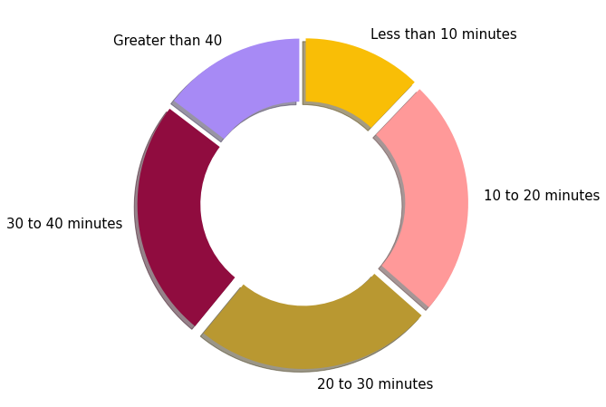

```python
#f9be06, #9f7d12,#b99831, #f5db8a, #a78af5
colors = ['#f9be06', '#ff9999','#b99831', '#900C3F', '#a78af5']
labels=['Less than 10 minutes', '10 to 20 minutes', '20 to 30 minutes', '30 to 40 minutes', 'Greater than 40']
# sizes= [12.1, 24.3, 24.437, 24.431, 14.6]
sizes=(less_ten, ten_twenty, twenty_thirty, thirty_forty, greater_forty)
explode = (0.05, 0.05, 0.05, 0.05, 0.05)
plt.figure(figsize=[8,8])
plt.pie(sizes,
        labels=labels,
#         autopct='%1.1f%%',
        startangle=90,
        counterclock=False,
        wedgeprops={'width':0.4},
        colors=colors,
        shadow=True,
        pctdistance=0.85,
        explode=explode);
plt.rcParams['font.size']=15

plt.show()
```

## 6. Prevailing Channel used to make calls

```python
# show the different calling platforms
calls_clean.channel.unique()
```

```
array(['Call-Center', 'Chatbot', 'Email', 'Web'], dtype=object)
```

```python
calls_clean.channel.value_counts()
```

```
Call-Center    10639
Chatbot         8256
Email           7470
Web             6576
Name: channel, dtype: int64
```

> **Let's visualize the numbers of calls received through the different channels**

[figure not shown]

```python
# Return the Series having unique values
x = calls_clean['channel'].unique()

# Return the Series having frequency count of each unique value
y = calls_clean['channel'].value_counts(sort=False)

# Size of the chart
plt.figure(figsize=(10,8))

# Add data to the chart
e=sns.barplot(x,y,color='olive')
e.bar_label(a.containers[0], fontsize=20, weight="bold")

# Labeling the axes
# x label
plt.xlabel('Response time', fontsize=20)
# y label
plt.ylabel('Count', fontsize=20)

# Add title
plt.title("Number of calls received by channels", fontsize=20, weight="bold");


plt.grid(axis="y",color = 'grey', linestyle = '--', linewidth = 1.5)
plt.show()
```

**This shows that the call centers received most calls. The Web seems to be an ineffective method of receiving calls**

> **Let's view the percentage count each channel contributes to the total number of calls received**

```python
call_center=10639/calls.channel.value_counts().sum() * 100
chatbot=8256/calls.channel.value_counts().sum() * 100
email=7470/calls.channel.value_counts().sum() * 100
web=6576/calls.channel.value_counts().sum() * 100


print(f'Call Center: , {call_center:.1f}')
print(f'Chatbot: , {chatbot:.1f}')
print(f'Email: , {email:.1f}')
print(f'Web: , {web:.1f}')
```

```
Call Center: , 32.3
Chatbot: , 25.1
Email: , 22.7
Web: , 20.0
```

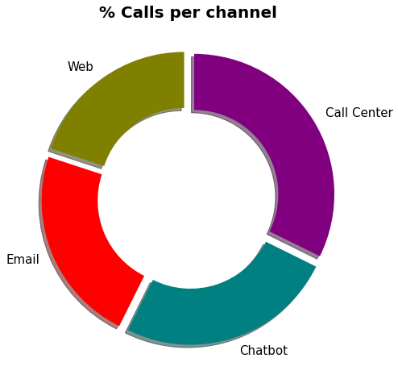

```python
#008080, #808000, #800080, #0000FF, #FF0000
colors = ['#800080', '#008080','#FF0000', '#808000']
labels=['Call Center', 'Chatbot', 'Email', 'Web']
sizes= (call_center, chatbot, email, web)
explode = (0.05, 0.05, 0.05, 0.05)

# pie chart size
plt.figure(figsize=[8,8])

# pie chart formatting
plt.pie(sizes,
        labels=labels,
#         autopct='%1.1f%%',
        startangle=90,
        counterclock=False,
        wedgeprops={'width':0.4},
        colors=colors,
        shadow=True,
        pctdistance=0.85,
        explode=explode,);
plt.rcParams['font.size']=15

# Add title
plt.title("% Calls per channel", fontsize=20, weight="bold")

plt.show()
```

**Call centers received the highest number of calls. The Chatbot and Email received almost a similar number if calls while the Web recieved the lowest number of calls**

# Which days received the highest number of calls?

```python
import datetime as dt
calls_clean['date'] =  pd.to_datetime(calls_clean['call_timestamp']) ## pandas recognizes your format

calls_clean['day'] = calls_clean['date'].dt.day
calls_clean['month'] = calls_clean['date'].dt.month
calls_clean['year'] = calls_clean['date'].dt.year
# calls_clean['weekday'] = calls_clean['call_timestamp'].dt.day_name
```

```python
calls_clean.sample(2)
```

|  | sentiment | csat_score | call_timestamp | reason | city | state | channel | response_time | call duration in minutes | call_center | date | day | month | year |
| --- | --- | --- | --- | --- | --- | --- | --- | --- | --- | --- | --- | --- | --- | --- |
| 28150 | Neutral | 5.548448 | 2020-10-06 | Billing Question | Riverside | California | Chatbot | Within SLA | 27 | Chicago/IL | 2020-10-06 | 6 | 10 | 2020 |
| 31270 | Neutral | 5.548448 | 2020-10-01 | Service Outage | El Paso | Texas | Chatbot | Within SLA | 12 | Los Angeles/CA | 2020-10-01 | 1 | 10 | 2020 |

```python
calls_clean.year.unique()
```

```
array([2020], dtype=int64)
```

```python
calls_clean.month.unique()
```

```
array([10], dtype=int64)
```

**All the calls were made in the year 2020, only in October**

```python
calls_clean.day.unique()
```

```
array([29,  5,  4, 17, 28, 16, 21,  3,  7,  9, 11,  2, 10,  6, 18, 30, 26,
       12,  8, 22,  1, 27, 13, 19, 23, 14, 25, 15, 24, 20, 31],
      dtype=int64)
```

```python
# convert day_name column to the name of the days that received the calls
calls_clean['day_name']=calls_clean.date.dt.day_name()
calls_clean['day_name'].unique()
```

```
array(['Thursday', 'Monday', 'Sunday', 'Saturday', 'Wednesday', 'Friday',
       'Tuesday'], dtype=object)
```

```python
# total number of calls received per day
calls_clean['day_name'].value_counts()
```

```
Friday       5570
Thursday     5481
Wednesday    4449
Tuesday      4408
Saturday     4403
Monday       4334
Sunday       4296
Name: day_name, dtype: int64
```

```python
calls_clean['day_name'].value_counts().mean()
```

```
4705.857142857143
```

> **Fridays and Thursdays received the highest number of calls**

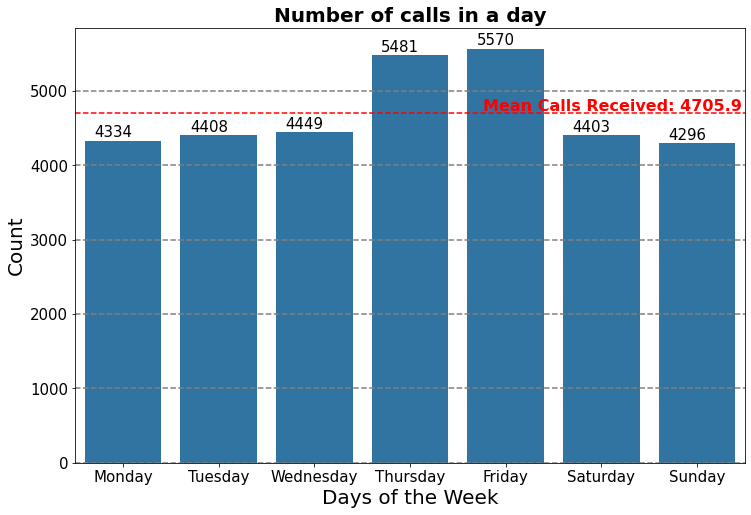

```python
plt.figure(figsize=[12,8])
base_color=sns.color_palette()[0]
ax=sns.countplot(data=calls_clean,
                 x=calls_clean['day_name'],
                 order=["Monday", "Tuesday", "Wednesday", "Thursday", "Friday", "Saturday", "Sunday"],
                 color=base_color)

plt.axhline(y = calls_clean["day_name"].value_counts().mean(),
            color = 'r',
            linestyle = '--')

plt.text(3.76, 4730,
         'Mean Calls Received: {:.1f}'.format(calls_clean["day_name"].value_counts().mean()),
         size=16,
         color="red",
         fontweight="bold")

for p in ax.patches:
        ax.annotate('{:.0f}'.format(p.get_height()), (p.get_x()+0.1, p.get_height()+50))

# Add title
plt.title("Number of calls in a day", fontsize=20, weight="bold")


# Add y label
plt.ylabel("Count", fontsize=20)

# Add x label
plt.xlabel("Days of the Week", fontsize=20)

plt.grid(axis="y",color = 'grey', linestyle = '--', linewidth = 1.5)
plt.show()
```

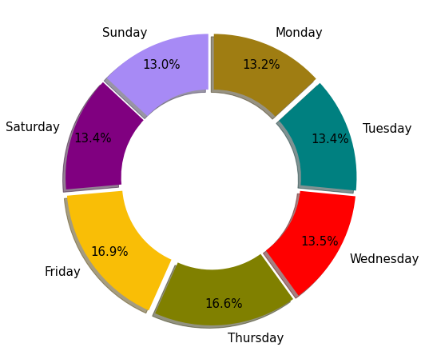

```python
#008080, #808000, #800080, #0000FF, #FF0000, #f9be06, #9f7d12,#b99831, #f5db8a, #a78af5
colors = ['#9f7d12', '#008080','#FF0000', '#808000', '#f9be06', '#800080', '#a78af5']
labels=['Monday', 'Tuesday', 'Wednesday', 'Thursday', 'Friday', 'Saturday', 'Sunday']
sizes= [4334, 4408, 4449, 5481, 5570, 4403, 4296]
explode = (0.05, 0.05, 0.05, 0.05, 0.05, 0.05, 0.05)
plt.figure(figsize=[8,8])
plt.pie(sizes,
        labels=labels,
        autopct='%1.1f%%',
        startangle=90,
        counterclock=False,
        wedgeprops={'width':0.4},
        colors=colors,
        shadow=True,
        pctdistance=0.85,
        explode=explode,);
plt.rcParams['font.size']=15
```

**As shown from the histogram above, the average number of calls received in overall is 4705. Thursdays and Fridays are the only days that have surpassed the average number of calls overall which contributes to 33.5% of the total calls received. Sunday receives the least number of calls in a number compared to the other days of the week**

```python
calls_clean['day'].value_counts()
```

```
21    1170
22    1167
6     1152
28    1144
16    1132
9     1123
17    1123
30    1120
13    1117
23    1111
15    1105
19    1102
24    1098
18    1097
10    1092
```

[output cut: 17 more lines]

> **21st recieved the highest number of calls recieved while 31st received 1 call**

# Bivariate Exploration

```python
calls_clean.corr(method='pearson')
```

|  | csat_score | call duration in minutes | day | month | year |
| --- | --- | --- | --- | --- | --- |
| csat_score | 1.000000 | -0.006094 | 0.001400 | NaN | NaN |
| call duration in minutes | -0.006094 | 1.000000 | -0.004184 | NaN | NaN |
| day | 0.001400 | -0.004184 | 1.000000 | NaN | NaN |
| month | NaN | NaN | NaN | NaN | NaN |
| year | NaN | NaN | NaN | NaN | NaN |

**There is no correlation between the columns**

```python
!jupyter nbconvert Call_Center_Analysis.ipynb --to slides --post serve --no-input --no-prompt
```

[output not shown]

# Conclusions

Another reason that could have contributed to the high negative sentiments could be due to the SLA. In as much as we have most calls within SLA (62.6%) which is a positive sign, calls Above SLA have the least contribution (12.7%) while that Below SLA is 24.7% and that shouldn't be the case.

However that doesn't necessary to a correlation of causation of having negative sentiments and the Service Level Agreements. The negative sentiments could be completely related to the products offered by the institution and not the customer care services.